# Rezultatai

Dovydas Kičiatovas

2018 m. gegužės 22 d.

# “Mašininio mokymosi metodų panaudojimas vėžio potipių identifikavimui”

## Darbo rezultatai

Šiame *R Markdown* faile sugeneruojami visi rezultatai - grafikai, paveikslėliai ir t.t. iš “Mašininio mokymosi metodų panaudojimas vėžio potipių identifikavimui” bakalaurinio darbo. Dėl reikalingo duomenų parsiuntimo ir skaičiavimų kiekio rezultatų generavimas gali užtrukti apie 10 min.

Pateikiamos kviečiamos funkcijos, jų aprašymai ir išvedama informacija. Reikalingi paketai ir nuorodos į jas:

- Bioconductor - https://bioconductor.org/
- TCGAbiolinks - https://bioconductor.org/packages/release/bioc/html/TCGAbiolinks.html
- ComplexHeatmap - https://bioconductor.org/packages/release/bioc/html/ComplexHeatmap.html
- data.table - https://cran.r-project.org/web/packages/data.table/index.html
- combinat - https://cran.r-project.org/web/packages/combinat/index.html
- randomForest - https://cran.r-project.org/web/packages/randomForest/index.html
- e1071 - https://cran.r-project.org/web/packages/e1071/index.html
- ROCR - https://cran.r-project.org/web/packages/ROCR/index.html
- klaR - https://cran.r-project.org/web/packages/klaR/index.html
- RANN - https://cran.r-project.org/web/packages/RANN/index.html
- survival - https://cran.r-project.org/web/packages/survival/index.html
- ggkm - https://github.com/michaelway/ggkm
- circlize - https://cran.r-project.org/web/packages/circlize/index.html
- githubinstall - https://cran.r-project.org/web/packages/githubinstall/index.html

Kodo rašymui naudotos 3.4 R ir 1.1.423 RStudio versijos.

## Programinės aplinkos paruošimas

Žemiau pateiktas kodas įrašo reikalingus paketus. Paketai užkraunami kviečiant tuos paketus naudojančias funkcijas.

```r
source("https://bioconductor.org/biocLite.R")
biocLite(ask = FALSE, suppressUpdates = TRUE)

if(!require(ComplexHeatmap)) { biocLite("ComplexHeatmap") }
if(!require(TCGAbiolinks)) { biocLite("TCGAbiolinks") }
if(!require(devtools)){
  install.packages("devtools", repos="https://cran.rstudio.com/") }
if(!require(data.table)){
  install.packages("data.table", repos="https://cran.rstudio.com/") }
if(!require(combinat)){
  install.packages("combinat", repos="https://cran.rstudio.com/") }
if(!require(randomForest)){
  install.packages("randomForest", repos="https://cran.rstudio.com/") }
if(!require(e1071)){
  install.packages("e1071", repos="https://cran.rstudio.com/") }
if(!require(ROCR)){
  install.packages("ROCR",  repos="https://cran.rstudio.com/") }
if(!require(klaR)){
  install.packages("klaR", repos="https://cran.rstudio.com/") }
if(!require(RANN)){
  install.packages("RANN", repos="https://cran.rstudio.com/") }
if(!require(survival)){
  install.packages("survival", repos="https://cran.rstudio.com/") }
if(!require(circlize)){
  install.packages("circlize", repos="https://cran.rstudio.com/") }
if(!require(githubinstall)){
  install.packages("githubinstall", repos="https://cran.rstudio.com/") }
if(!require(ggkm)){
  library(githubinstall); githubinstall("michealway/ggkm", ask = FALSE) }
```

Visi reikalingi *R* kodo failai. Failuose “classification_analysis.R”, “roc.R”, “hybrid.R”, “draw_heatmap.R” ir “therapy_analysis.R” yra nustatytos pseudo-atsitiktinių skaičių generatorių *seed* reikšmės rezultatų pakartojamumui pasiekti. Kodas visuose failuose stilizuotas taip, kad eilutės ilgiai neviršytų 80 simbolių. **Nepamirškite, kad direktorijoje, kurioje šis *Markdown* failas yra, turi** **būti toliau išvardyti failai, taip pat klinikinių duomenų failas** **“gliovis_clinical_data.txt” bei pavyzdinis *Random Forest* modelis** **“rf_model.RData”!**

```r
source("data.R", encoding = "utf-8")
source("linear_regression.R", encoding = "utf-8")
source("classification_analysis.R", encoding = "utf-8")
source("variable_importance.R", encoding = "utf-8")
source("roc.R", encoding = "utf-8")
source("hybrid.R", encoding = "utf-8")
source("survival_analysis.R", encoding = "utf-8")
source("draw_heatmap.R", encoding = "utf-8")
source("therapy_analysis.R", encoding = "utf-8")
```

## Duomenų gavimas

Duomenų gavimas iš TCGA duomenų bazės. Grąžina miRNR ekspresijų objektą. Taip pat nuskaitomas pateiktas klinikinių duomenų failas. Pastaba: kartu su šiuo *Markdown* failų pateikti ir parsiųsti duomenys. Norint dar kartą įvykdyti siuntimą, reikia ištrinti “GDCdata” aplanką.

```r
mirna_data <- getData()
```

Turimų pacientų duomenų glioblastomos potipių (klasikinis, mezenchiminis, nervinis, pronervinis) kiekiai:

```r
summary(mirna_data$Subtype)
```

```
##   Classical Mesenchymal      Neural   Proneural
##         139         150          78         130
```

## Tiesinės regresijos analizė

Žemiau pateikti pavyzdinės miRNR (hsa-miR-139) ekspresijos lygiai skirtinguose potipiuose ir atitinkamos miRNR ekspresijų taškinis grafikas kartu su tiesinės regresijos tiese.

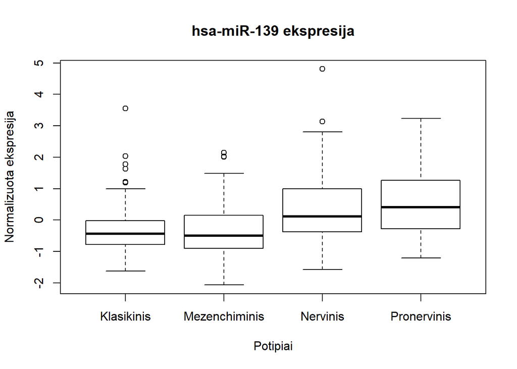

```r
model <- lm(as.numeric(mirna_data[["hsa-miR-139"]]) ~ mirna_data$Subtype)
boxplot(as.numeric(mirna_data[["hsa-miR-139"]]) ~ mirna_data$Subtype,
        main = "hsa-miR-139 ekspresija", xaxt = "n",
        xlab = "Potipiai", ylab = "Normalizuota ekspresija")
axis(1, at=1:4, labels=c("Klasikinis", "Mezenchiminis",
                         "Nervinis", "Pronervinis"))
```

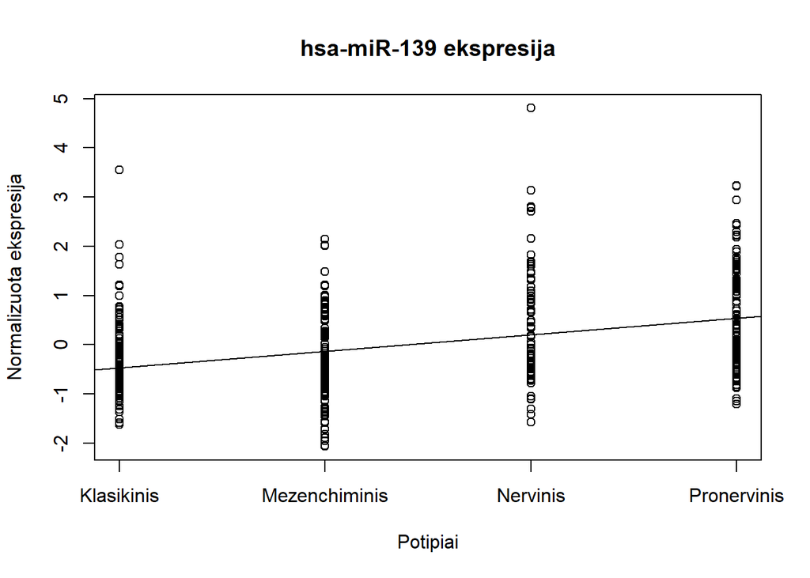

```r
model <-
  lm(as.numeric(mirna_data[["hsa-miR-139"]]) ~ as.numeric(mirna_data$Subtype))
plot(as.numeric(mirna_data[["hsa-miR-139"]]) ~ as.numeric(mirna_data$Subtype),
     main = "hsa-miR-139 ekspresija", xaxt = "n",
     xlab = "Potipiai", ylab = "Normalizuota ekspresija")
axis(1, at=1:4, labels=c("Klasikinis", "Mezenchiminis",
                         "Nervinis", "Pronervinis"))
abline(model)
```

Žemiau pavaizduotos tiesinės regresijos analizės metu kaip geras klasifikatorius atmestos (hsa-miR-144) ir priimtos (hsa-miR-21) miRNR grafikai.

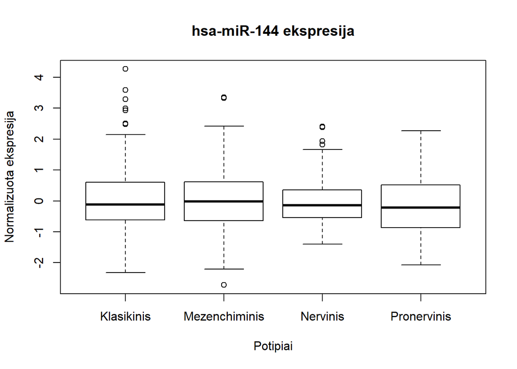

```r
model <- lm(as.numeric(mirna_data[["hsa-miR-144"]]) ~ mirna_data$Subtype)
boxplot(as.numeric(mirna_data[["hsa-miR-144"]]) ~ mirna_data$Subtype,
        main = "hsa-miR-144 ekspresija", xaxt = "n",
        xlab = "Potipiai", ylab = "Normalizuota ekspresija")
axis(1, at=1:4, labels=c("Klasikinis", "Mezenchiminis",
                         "Nervinis", "Pronervinis"))
```

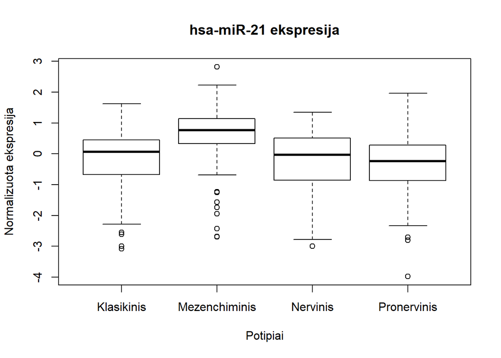

```r
model <-
  lm(as.numeric(mirna_data[["hsa-miR-21"]]) ~ mirna_data$Subtype)
boxplot(as.numeric(mirna_data[["hsa-miR-21"]]) ~ mirna_data$Subtype,
        main = "hsa-miR-21 ekspresija", xaxt = "n",
        xlab = "Potipiai", ylab = "Normalizuota ekspresija")
axis(1, at=1:4, labels=c("Klasikinis", "Mezenchiminis",
                         "Nervinis", "Pronervinis"))
```

Tiesinės regresijos analizė: funkcija reikalauja miRNR ekspresijų objekto (gauto iš getData()), tiesės koeficiento absoliučios reikšmės ribos (neprivaloma, numatyta reikšmė - 0,24) ir grąžina miRNR sąrašą, sudarytą pagal nustatytą koeficiento ribą (su 0,24 gaunamas 93 miRNR sąrašas).

```r
lm_mirna_list <- linearRegression(mirna_data)
```

## Potipių klasifikavimas

Klasifikavimo analizė: funkcija reikalauja miRNR ekspresijos duomenų failo (pateikiamas miRNR ekspresijų objektas be “Sample” identifikatorių stulpelio, su norimų miRNR stulpeliais ir potipiais.) ir duomenų proporcijos treniravimo aibei (numatytoji - 0,9). Išveda tik tekstinę informaciją.

```r
classificationAnalysis(mirna_data[, c(lm_mirna_list, "Subtype")])
```

```
## Parametrai:
## Treniruojama 90 proc. visų duomenų.
## Klasifikuojama 93 miRNR duomenimis.
##
## Random Forest
## 1 bandymas: 0.7755102
## 2 bandymas: 0.6122449
## 3 bandymas: 0.7346939
## 4 bandymas: 0.755102
## 5 bandymas: 0.6530612
## 6 bandymas: 0.7346939
## 7 bandymas: 0.6938776
## 8 bandymas: 0.6938776
## 9 bandymas: 0.755102
## 10 bandymas: 0.755102
```

[output cut: 105 more lines]

Random Forest ROC kreivės piešimas. Funkcija reikalauja miRNR ekspresijų objekto (be “Sample” identifikatorių) ir duomenų aibės proporcijos treniruotei (numatytoji - 0.9). Piešia ROC grafiką.

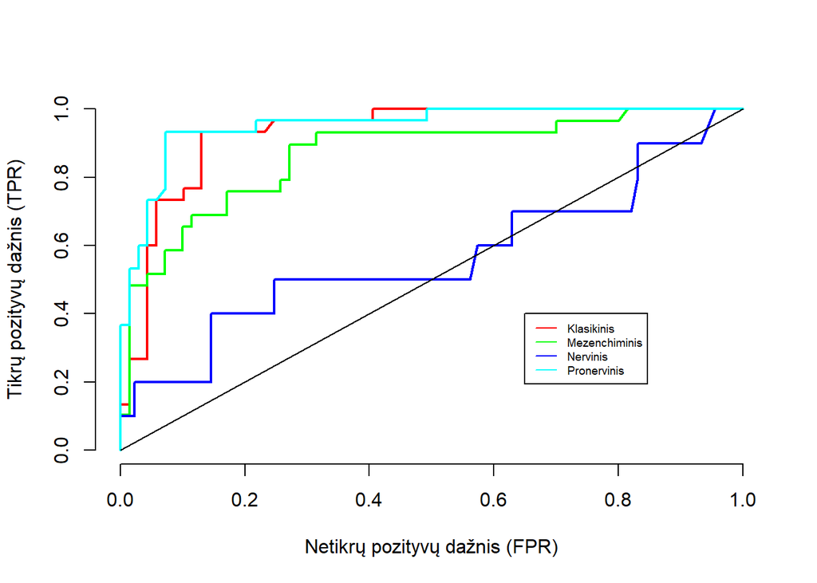

```r
roc(mirna_data[, c(lm_mirna_list, "Subtype")], 0.8)
```

Aprašytas 73 proc. tikslumo Random Forest modelis. Naudojimui su variableImportance funkcija.

```r
rf_model <- get(load("./rf_model.RData"))
rf_model
```

```
##
## Call:
##  randomForest(formula = Subtype ~ ., data = train)
##                Type of random forest: classification
##                      Number of trees: 500
## No. of variables tried at each split: 9
##
##         OOB estimate of  error rate: 31.23%
## Confusion matrix:
##             Classical Mesenchymal Neural Proneural class.error
## Classical          91          20      3         7   0.2479339
## Mesenchymal        18          84      3         4   0.2293578
## Neural             27          11      9        16   0.8571429
## Proneural          10           4      1        89   0.1442308
```

Kintamųjų svarba iš pateikto Random Forest modelio. Reikalauja RF modelio ir norimo kintamųjų skaičiaus. Grąžina kintamųjų sąrašą ir piešia kintamųjų svarbos grafiką.

```r
top_classifier_list <- variableImportance(rf_model, 20)
```

```
## Parametrai:
## Svarbiausių miRNR skaičius: 20
```

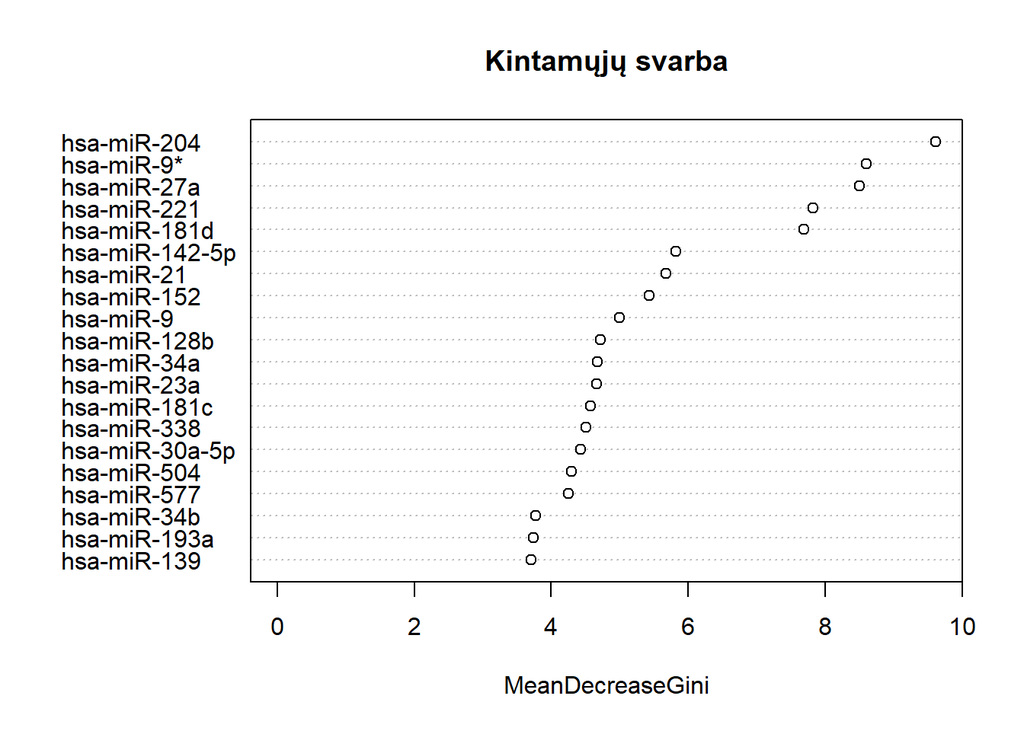

```
##
## Call:
##  randomForest(formula = Subtype ~ ., data = train)
##                Type of random forest: classification
##                      Number of trees: 500
## No. of variables tried at each split: 9
##
##         OOB estimate of  error rate: 31.23%
## Confusion matrix:
##             Classical Mesenchymal Neural Proneural class.error
## Classical          91          20      3         7   0.2479339
## Mesenchymal        18          84      3         4   0.2293578
## Neural             27          11      9        16   0.8571429
## Proneural          10           4      1        89   0.1442308
```

Intensyvumo žemėlapis (*heatmap*), vaizduojantis iš kintamųjų svarbos gautojo miRNR sąrašo ekspresijos intensyvumą pacientuose. Funkcija reikalauja miRNR ekspresijos duomenų failo (pateikiamas miRNR ekspresijų objektas be “Sample” identifikatorių stulpelio, su norimų miRNR stulpeliais ir potipiais), loginio indikatoriaus, žyminčio, ar skirstyti pacientus pagal išgyvenamumą, kartu vaizduojant ir pacientų CIMP, IDH1 būsenas ir dviejų išgyvenamumo grupių skirstymo ribos (numatytoji - 12 mėn.), jei prieš tai minėtasis loginis indikatorius yra *TRUE*.

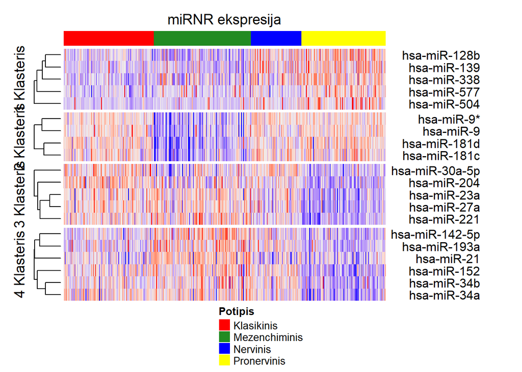

```r
drawHeatmap(mirna_data[, c("Sample", top_classifier_list, "Subtype")])
```

Hibridinis klasifikatorius. Funkcija reikalauja miRNR ekspresijų objekto (be “Sample” identifikatorių), skaičiaus k (numatytasis - 10) artimiausiems kaimynams rasti ir duomenų proporcijos treniruotei (numatytoji - 0,9). Išveda tik tekstinę informaciją.

```r
hybridClassifier(mirna_data[, c(lm_mirna_list, "Subtype")], 12)
```

```
## Parametrai:
## Treniruojama 90 proc. visų duomenų.
## Klasifikuojama 93 miRNR duomenimis.
## Artimiausiems kaimynams rasti: k = 12
##
## RandomForest / Hibridinis klas.
## 1 bandymas:  0.6938776   0.6734694
## 2 bandymas:  0.6734694   0.6938776
## 3 bandymas:  0.7959184   0.7755102
## 4 bandymas:  0.7142857   0.6938776
## 5 bandymas:  0.7755102   0.755102
## 6 bandymas:  0.7346939   0.7142857
## 7 bandymas:  0.6938776   0.6734694
## 8 bandymas:  0.5510204   0.5714286
## 9 bandymas:  0.7346939   0.7346939
```

[output cut: 97 more lines]

## Išgyvenamumo analizė

Išgyvenamumo analizė. Funkcija reikalauja miRNR ekspresijų objekto (kartu su “Sample” identifikatoriais), duomenų proporcijos treniruotei (numatytoji - 0,9), dviejų išgyvenamumo grupių skirstymo ribos (numatytoji - 12 mėn.) ir loginis indikatorius, žymintis, ar naudoti Random Forest klasifikavimą. Iš GitHub repozitorijos nuskaito klinikinių duomenų failą. Piešiami 3 grafikai - išgyvenamumo histograma, tankio grafikas ir Kaplan-Mieier kreivės.

```r
survivalAnalysis(mirna_data[, c("Sample", lm_mirna_list, "Subtype")])
```

```
## Parametrai:
## Treniruojama 90 proc. visų duomenų.
## Klasifikuojama 93 miRNR duomenimis.
##
## 1 grupė:  247 pacientai.
## 2 grupė:  250 pacientai.
```

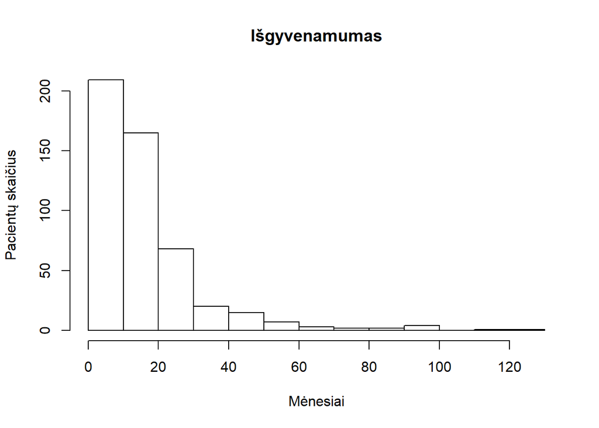

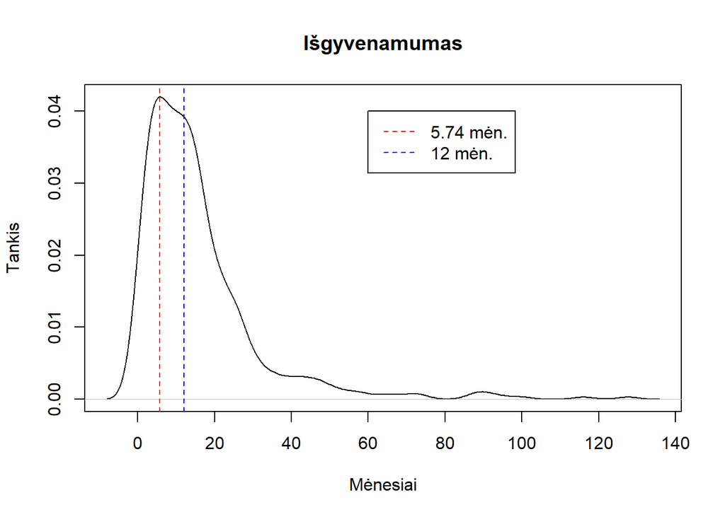

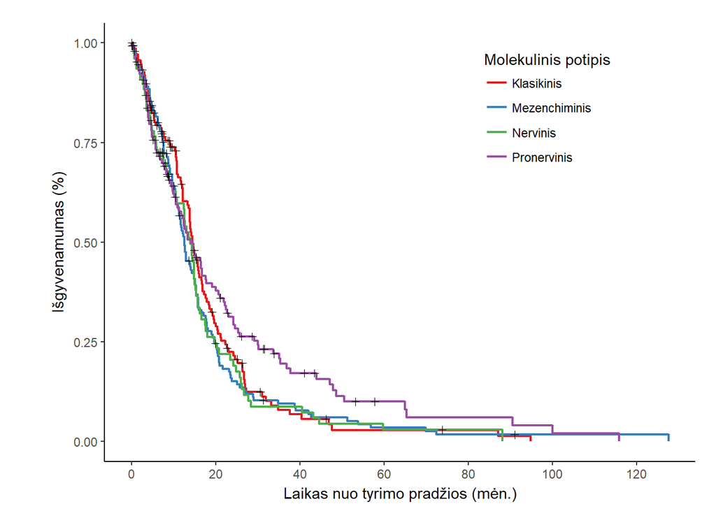

```
## Nupiešti 3 grafikai.
##
## Naive Bayes apriori tikimybės:
## Y
##       Yes        No
## 0.5030181 0.4969819
##
## Naive Bayes klaidų matrica:
##
## Naive Bayes tikslumas:  0.5895372
##
## Kolmogorov-Smirnov testai:
## Testas / p-reikšmė / miRNR / Potipis
## KS:  0.02224 hsa-miR-214 Classical
## KS:  0.01507 hsa-miR-33  Classical
## KS:  0.01802 hsa-miR-422b    Classical
## KS:  0.00346 hsa-miR-204 Mesenchymal
## KS:  0.02441 hsa-miR-302c*   Mesenchymal
## KS:  7e-04   hsa-miR-330 Mesenchymal
## KS:  0.00552 hsa-miR-9   Mesenchymal
## KS:  0.01151 hsa-miR-93  Mesenchymal
## KS:  0.01072 hsa-miR-99b Mesenchymal
## KS:  0.00537 hsa-miR-148a    Proneural
## KS:  0.02023 hsa-miR-155 Proneural
## KS:  0.00333 hsa-miR-17-3p   Proneural
## KS:  0.01689 hsa-miR-22  Proneural
## KS:  0.01799 hsa-miR-221 Proneural
## KS:  0.00239 hsa-miR-34a Proneural
## KS:  1e-05   hsa-miR-34b Proneural
## KS:  0.00732 hsa-miR-504 Proneural
## KS:  0.01454 hsa-miR-92  Proneural
```

## Terapijų grupių analizė

Terapijų grupių analizė. Funkcija reikalauja miRNR ekspresijų objekto (kartu su “Sample” identifikatoriais), dviejų išgyvenamumo grupių skirstymo ribos (numatytoji - 12 mėn.).

```r
therapyAnalysis(mirna_data[, c("Sample", lm_mirna_list, "Subtype")])
```

```
## Stand. radiacija: 50 pac.
## Stand. radiacija / TMZ: 76 pac.
## TMZ: 203 pac.
##
## Std. Rad. vs Rad/TMZ + TMZ
## Bootstrapping...
## Classical ... Done.
## Mesenchymal ... Done.
## Neural ... Done.
## Proneural ... Done.
##
## Results:
##
## Classical
## named integer(0)
##
## Mesenchymal
## named integer(0)
##
## Neural
## named integer(0)
##
## Proneural
## named integer(0)
##
## Rad/TMZ vs. Std. Rad. + TMZ
## Bootstrapping...
## Classical ... Done.
## Mesenchymal ... Done.
## Neural ... Done.
## Proneural ... Done.
##
## Results:
##
## Classical
## hsa-miR-106b   hsa-miR-93
##          509          683
##
## Mesenchymal
##  hsa-miR-331  hsa-miR-575  hsa-miR-598 hsa-miR-128b hsa-miR-128a
```

[output cut: 20 more lines]

```
##
## Mesenchymal
##   hsa-miR-125a    hsa-miR-598    hsa-miR-30c hsa-miR-769-5p     hsa-miR-95
##            571            636            659            689            714
##    hsa-miR-10b hsa-miR-454-3p   hsa-miR-128b    hsa-miR-198   hsa-miR-422b
##            734            789            811            876            880
##   hsa-miR-125b   hsa-miR-128a    hsa-miR-575
##            903            956            976
##
## Neural
## named integer(0)
##
## Proneural
## hsa-miR-218
##         580
```

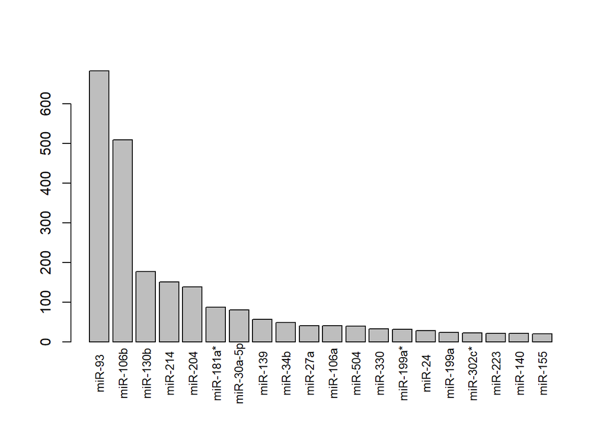

Pavaizduojamas miRNR intensyvumo žemėlapis kartu su pacientų išgyvenamumu ir CIMP bei IDH1 būsenomis.

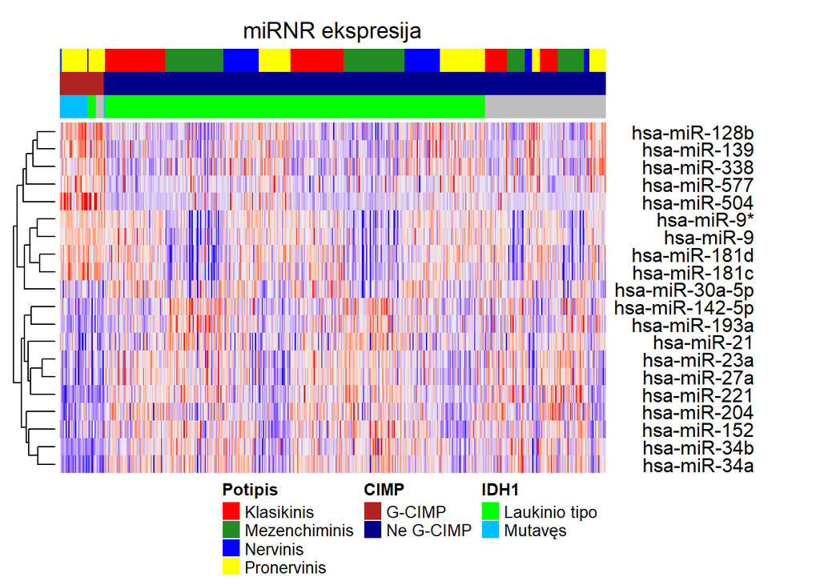

```r
drawHeatmap(mirna_data[, c("Sample", top_classifier_list, "Subtype")],
            cutoff = 12, surv = TRUE)
```